# RNA-seq Pipeline: Rsubread, limma, and edgeR

## Case study: using a Bioconductor R pipeline to analyze RNA-seq data

This example has been adapted from the work of:

Wei Shi (shi at wehi dot edu dot au), Yang Liao and Gordon K Smyth Bioinformatics Division, Walter and Eliza Hall Institute, Melbourne, Australia

- Case: http://bioinf.wehi.edu.au/RNAseqCaseStudy/
- Code: http://bioinf.wehi.edu.au/RNAseqCaseStudy/code.R
- Data: http://bioinf.wehi.edu.au/RNAseqCaseStudy/data.tar.gz

Requirements:

- The version of Rsubread package should be 1.12.1 or later.
- You should run R version 3.0.2 or later.

## Record the start time

```r
print(Sys.time())
```

```
## [1] "2015-03-05 12:12:48 PST"
```

## Setup

> Load libraries, read in names of FASTQ files and create a design matrix.

### Set options

Set global knitr options.

```r
library("knitr")
opts_chunk$set(tidy=FALSE, cache=FALSE, messages=FALSE)
```

### Install packages

```r
packages <- c("Rsubread", "limma", "edgeR")
source("http://bioconductor.org/biocLite.R")
```

```
## Bioconductor version 3.0 (BiocInstaller 1.16.1), ?biocLite for help
```

```r
for (pkg in packages)
{
    require(pkg, character.only = TRUE, quietly = TRUE) || biocLite(pkg)
}
```

### Load libraries

```r
library(Rsubread)
library(limma)
library(edgeR)
print(Sys.time())
```

```
## [1] "2015-03-05 12:12:50 PST"
```

### Download data file

```r
# Create the data folder if it does not already exist
datadir <- "./Data/rsubread_test"
dir.create(file.path(datadir), showWarnings=FALSE, recursive=TRUE)

# Enter data folder, first saving location of current folder
projdir <- getwd()
setwd(datadir)
datadir <- getwd()

# Get the file
dataurl <- "http://bioinf.wehi.edu.au/RNAseqCaseStudy/data.tar.gz"
datafile <- "data.tar.gz"
if (! file.exists(datafile)) {
    print("Downloading data file...")
    download.file(dataurl, datafile) # 282.3 Mb
}
```

```
## [1] "Downloading data file..."
```

```r
print(Sys.time())
```

```
## [1] "2015-03-05 12:19:17 PST"
```

### Extract data file

```r
setwd(datadir)
targetsfile <- "Targets.txt"
if (! file.exists(targetsfile)) {
    print("Extracting data file...")
    untar(datafile, tar="internal")
}
```

```
## [1] "Extracting data file..."
```

```r
print(Sys.time())
```

```
## [1] "2015-03-05 12:19:55 PST"
```

### Read target file

```r
setwd(datadir)
options(digits=2)
targets <- readTargets(targetsfile)
targets
```

```
##   CellType  InputFile OutputFile
## 1        A A_1.txt.gz    A_1.bam
## 2        A A_2.txt.gz    A_2.bam
## 3        B B_1.txt.gz    B_1.bam
## 4        B B_2.txt.gz    B_2.bam
```

```r
print(Sys.time())
```

```
## [1] "2015-03-05 12:19:55 PST"
```

### Create design matrix

```r
celltype <- factor(targets$CellType)
design <- model.matrix(~celltype)
print(Sys.time())
```

```
## [1] "2015-03-05 12:19:55 PST"
```

## Build reference

> Build an index for human chromosome 1. This typically takes ~3 minutes. Index files with basename ‘chr1’ will be generated in your current working directory.

```r
setwd(datadir)
buildindex(basename="chr1",reference="hg19_chr1.fa")
```

[output not shown]

[output cut: 16 more lines]

```
## ||  [ 10.0% finished ]                                                        ||
## ||  [ 20.0% finished ]                                                        ||
## ||  [ 30.0% finished ]                                                        ||
## ||  [ 40.0% finished ]                                                        ||
## ||  [ 50.0% finished ]                                                        ||
## ||  [ 60.0% finished ]                                                        ||
## ||  [ 70.0% finished ]                                                        ||
## ||  [ 80.0% finished ]                                                        ||
## ||  [ 90.0% finished ]                                                        ||
## ||  [ 100.0% finished ]                                                       ||
## ||                                                                            ||
## ||                      Total running time: 3.3 minutes.                      ||
## ||                     Index chr1 was successfully built!                     ||
## ||                                                                            ||
## \\===================== http://subread.sourceforge.net/ ======================//
```

```r
print(Sys.time())
```

```
## [1] "2015-03-05 12:23:11 PST"
```

## Align reads

```r
setwd(datadir)
align(index="chr1", readfile1=targets$InputFile,
      input_format="gzFASTQ", output_format="BAM",
      output_file=targets$OutputFile,
      tieBreakHamming=TRUE, unique=TRUE, indels=5)
```

[output not shown]

[output cut: 296 more lines]

```
## ||   98% completed,   1 mins elapsed, total=880k reads, rate=9.1k/s           ||
## ||                                                                            ||
## ||                          Completed successfully.                           ||
## ||                                                                            ||
## \\============================================================================//
##
## //================================= Summary ==================================\\
## ||                                                                            ||
## ||          Processed : 880316 reads                                          ||
## ||             Mapped : 818107 reads (92.9%)                                  ||
## ||             Indels : 4829                                                  ||
## ||                                                                            ||
## ||       Running time : 1.6 minutes                                           ||
## ||                                                                            ||
## \\===================== http://subread.sourceforge.net/ ======================//
```

```r
print(Sys.time())
```

```
## [1] "2015-03-05 12:28:43 PST"
```

## Summarize mapped reads

Count numbers of reads mapped to NCBI Refseq genes.

> Summarize mapped reads to RefSeq genes. This will just take a few seconds. Note that the featureCounts function has built-in annotation for Refseq genes. featureCounts returns an R ‘List’ object, which includes raw read count for each gene in each library and also annotation information for genes such as gene identifiers and gene lengths.

```r
setwd(datadir)
fc <- featureCounts(files=targets$OutputFile,annot.inbuilt="hg19")
```

[output not shown]

[output cut: 13 more lines]

```
## ||    Assign reads to features...                                             ||
## ||    Total reads : 902841                                                    ||
## ||    Successfully assigned reads : 448593 (49.7%)                            ||
## ||    Running time : 0.05 minutes                                             ||
## ||                                                                            ||
## || Process BAM file B_2.bam...                                                ||
## ||    Single-end reads are included.                                          ||
## ||    Assign reads to features...                                             ||
## ||    Total reads : 880316                                                    ||
## ||    Successfully assigned reads : 435938 (49.5%)                            ||
## ||    Running time : 0.05 minutes                                             ||
## ||                                                                            ||
## ||                         Read assignment finished.                          ||
## ||                                                                            ||
## \\===================== http://subread.sourceforge.net/ ======================//
```

```r
x <- DGEList(counts=fc$counts, genes=fc$annotation[,c("GeneID","Length")])
# Return to projdir
setwd(projdir)
print(Sys.time())
```

```
## [1] "2015-03-05 12:28:56 PST"
```

## Generate RPKM values

Generate RPKM values if you need them.

```r
x_rpkm <- rpkm(x,x$genes$Length)
print(Sys.time())
```

```
## [1] "2015-03-05 12:28:56 PST"
```

## Filter out low-count genes

> Only keep in the analysis those genes which had >10 reads per million mapped reads in at least two libraries.

```r
isexpr <- rowSums(cpm(x) > 10) >= 2
x <- x[isexpr,]
print(Sys.time())
```

```
## [1] "2015-03-05 12:28:56 PST"
```

## Perform voom normalization

> The figure below shows the mean-variance relationship estimated by voom for the data.

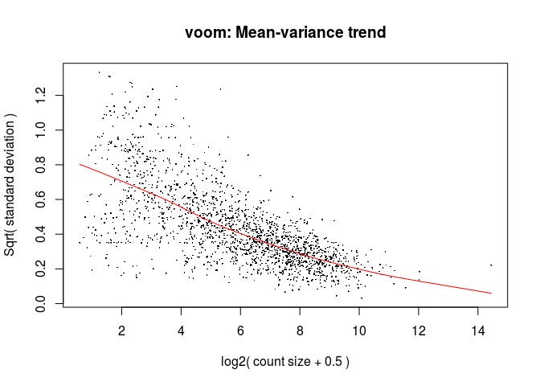

```r
y <- voom(x,design,plot=TRUE)
```

```r
print(Sys.time())
```

```
## [1] "2015-03-05 12:28:56 PST"
```

## Cluster libraries

> The following multi-dimensional scaling plot shows that sample A libraries are clearly separated from sample B libraries.

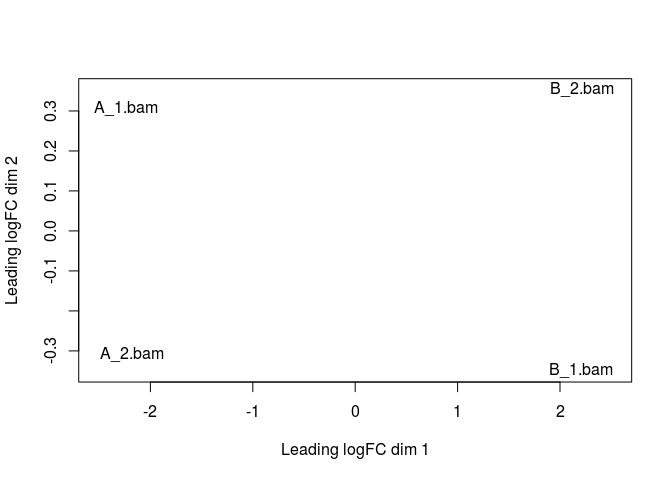

```r
plotMDS(y,xlim=c(-2.5,2.5))
```

```r
print(Sys.time())
```

```
## [1] "2015-03-05 12:28:56 PST"
```

## Assess differential expression

Fit linear model and assess differential expression.

> Fit linear models to genes and assess differential expression using the eBayes moderated t statistic. Here we list top 10 differentially expressed genes between B vs A.

```r
fit <- eBayes(lmFit(y,design))
topTable(fit,coef=2)
```

```
##              GeneID Length logFC AveExpr   t P.Value adj.P.Val  B
## 100131754 100131754   1019   1.6      16 113 3.5e-28   6.3e-25 54
## 2023           2023   1812  -2.7      13 -91 2.2e-26   1.9e-23 51
## 2752           2752   4950   2.4      13  82 1.5e-25   9.1e-23 49
## 22883         22883   5192   2.3      12  64 1.8e-23   7.9e-21 44
## 6135           6135    609  -2.2      12 -62 3.1e-23   9.5e-21 44
## 6202           6202    705  -2.4      12 -62 3.2e-23   9.5e-21 44
## 4904           4904   1546  -3.0      11 -60 5.5e-23   1.4e-20 43
## 23154         23154   3705   3.7      11  55 2.9e-22   6.6e-20 41
## 8682           8682   2469   2.6      12  49 2.2e-21   4.3e-19 39
## 6125           6125   1031  -2.0      12 -48 3.1e-21   5.6e-19 39
```

```r
print(Sys.time())
```

```
## [1] "2015-03-05 12:28:57 PST"
```